# PA1_template.Rmd

ME!

1/3/2022

```r
originalData <- read.csv("activity.csv",header=TRUE)
datalessNA <- na.omit(originalData)
```

## 1. What is mean total number of steps taken per day?

## 1A. Calculate the total number of steps taken per day

```r
steps_each_day <- aggregate(datalessNA$steps, by= list(datalessNA$date), FUN="sum")
steps_each_day
```

```
##       Group.1     x
## 1  2012-10-02   126
## 2  2012-10-03 11352
## 3  2012-10-04 12116
## 4  2012-10-05 13294
## 5  2012-10-06 15420
## 6  2012-10-07 11015
## 7  2012-10-09 12811
## 8  2012-10-10  9900
## 9  2012-10-11 10304
## 10 2012-10-12 17382
## 11 2012-10-13 12426
## 12 2012-10-14 15098
## 13 2012-10-15 10139
## 14 2012-10-16 15084
```

[output cut: 39 more lines]

## 1B. Make a histogram of the total number of steps taken each day

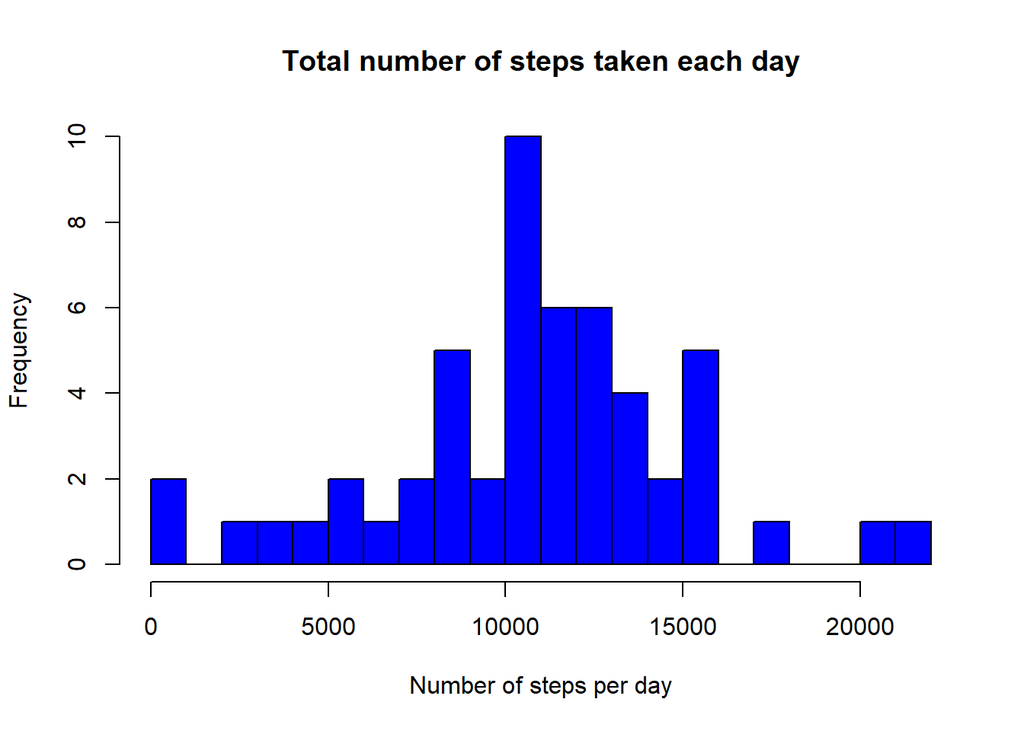

```r
hist(steps_each_day$x, col="blue", xlab = "Number of steps per day",
     main = "Total number of steps taken each day", breaks = 30)
```

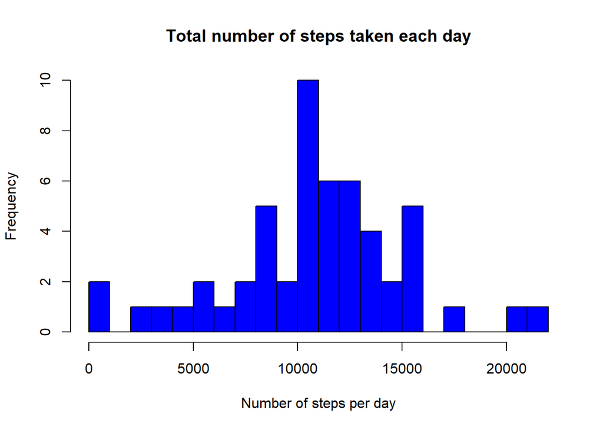

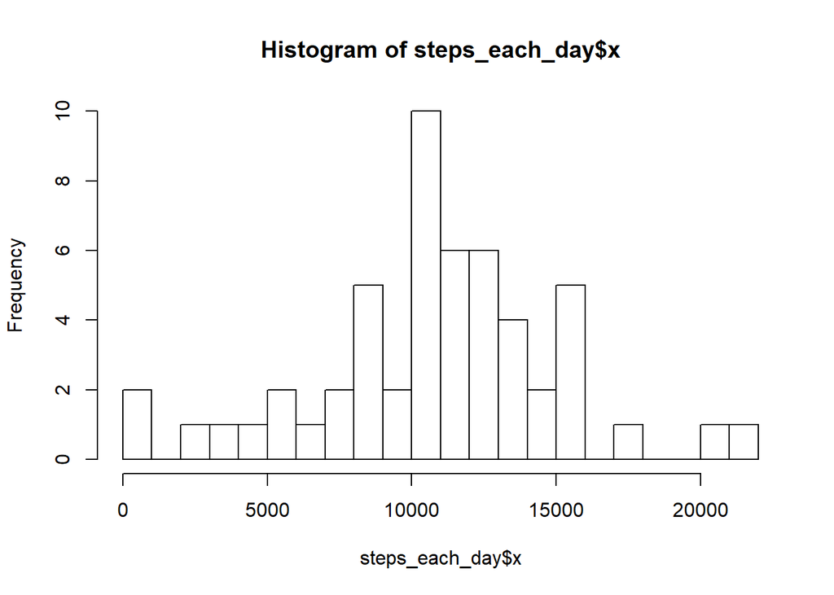

```r
plot(hist(steps_each_day$x, col="blue", xlab = "Number of steps per day",
     main = "Total number of steps taken each day", breaks = 30))
```

## 1C. Calculate and report the mean and median of the total number of steps taken per day

```r
mean_steps <- mean(steps_each_day[,2])
mean_steps
```

```
## [1] 10766.19
```

```r
median_steps <- median(steps_each_day[,2])
median_steps
```

```
## [1] 10765
```

## 2. What is the average daily activity pattern?

## 2A. Make a time series plot (i.e. type = “l”) of the 5-minute interval (x-axis) and the average number of steps taken, averaged across all days (y-axis)

```r
mean_each_day <- aggregate(datalessNA$steps, by = list(Interval = datalessNA$interval), FUN = "mean")
```

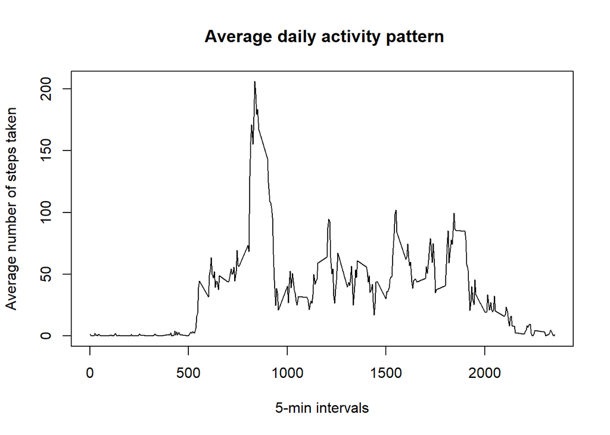

```r
plot(mean_each_day$Interval, mean_each_day$x, type = "l", xlab = "5-min intervals",
     ylab = "Average number of steps taken", main = " Average daily activity pattern")
```

## 2B. Which 5-minute interval, on average across all the days in the dataset, contains the maximum number of steps?

```r
interval_row <- which.max(mean_each_day$x)
max_interval <- mean_each_day[interval_row, 1]
max_interval
```

```
## [1] 835
```

## 3. Note that there are a number of days/intervals where there are missing values (coded as red NA). The presence of missing days may introduce bias into some calculations or summaries of the data.

## 3A. Calculate and report the total number of missing values in the dataset (i.e. the total number of rows with NAs)

```r
number_of_NAs <- length(which(is.na(originalData$steps)))
number_of_NAs
```

```
## [1] 2304
```

## 3B. Devise a strategy for filling in all of the missing values in the dataset. The strategy does not need to be sophisticated. For example, you could use the mean/median for that day, or the mean for that 5-minute interval, etc.

## 3C.Create a new dataset that is equal to the original dataset but with the missing data filled in.

```r
library(Hmisc)
originalData_filled <- originalData
originalData_filled$steps <- impute(originalData$steps, fun = mean)
```

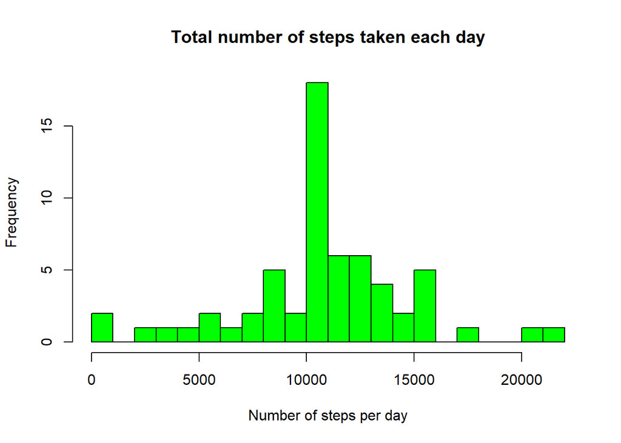

```r
steps_each_day_noNAs <- aggregate(originalData_filled$steps, by = list(originalData_filled$date), FUN="sum")
hist(steps_each_day_noNAs$x, col="green", xlab = "Number of steps per day",
     main = "Total number of steps taken each day", breaks = 30)
```

```r
mean_steps_NAsfilled <- mean(steps_each_day_noNAs[,2])
mean_steps_NAsfilled
```

```
## [1] 10766.19
```

```r
median_steps_NAsfilled <- median(steps_each_day_noNAs[,2])
median_steps_NAsfilled
```

```
## [1] 10766.19
```

## 5. Are there differences in activity patterns between weekdays and weekends?

## 5A. Create a new factor variable in the dataset with two levels – “weekday” and “weekend” indicating whether a given date is a weekday or weekend day.

```r
originalData_filled$date <- as.Date(originalData_filled$date)
originalData_filled$weekday <- weekdays(originalData_filled$date)
originalData_filled$weekend <- ifelse(originalData_filled$weekday == "Saturday" | originalData_filled$weekday == "Sunday", "Weekend", "Weekday")
```

## 5B. Make a panel plot containing a time series plot (i.e. type = “l”) of the 5-minute interval (x-axis) and the average number of steps taken, averaged across all weekday days or weekend days (y-axis). See the README file in the GitHub repository to see an example of what this plot should look like using simulated data.

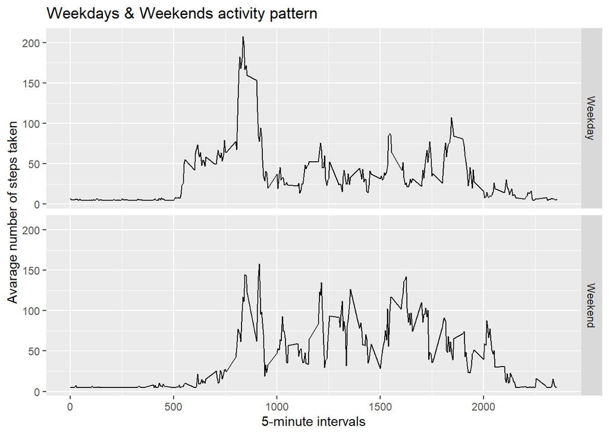

```r
day_type <- aggregate(steps ~ interval + weekend, data = originalData_filled, mean)
library(ggplot2)
ggplot(day_type, aes(interval, steps)) + geom_line() + facet_grid(weekend ~ .) +
        xlab("5-minute intervals") +
        ylab("Avarage number of steps taken") +
        ggtitle ("Weekdays & Weekends activity pattern")
```